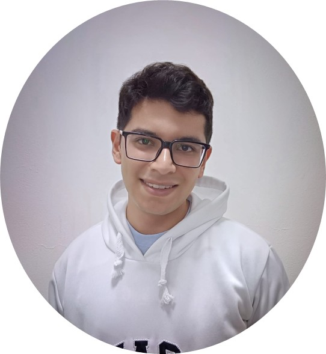

# Gabriel Ramirez-Vilchis

## About me

I am an undergraduate student in [Genomic Sciences](https://www.lcg.unam.mx/) at the [National Autonomous University of Mexico (UNAM)](https://www.unam.mx/).

My main interests include:

- **Immunology** and host–virus interactions
- **Erythropoiesis** and red blood cell development
- **Neuroscience**, particularly neurodevelopment and neurodegenerative diseases
- **Bioinformatics & Genomics**, especially RNA-seq and machine learning applications in biology

I aim to integrate experimental biology with computational approaches to better understand how cellular processes are regulated at the molecular level.

## Skills

- **Software Development & Data Analysis**: Python, R, Bash, C, Perl
- **Bioinformatics**: BLAST, Clustal Omega, MUSCLE, RNA-seq preprocessing (FastQC, STAR, DESeq2)
- **Collaborative Tools**: Git, GitHub, Jupyter Notebooks
- **Molecular Biology**: Microscopy, flow cytometry (basic level)
- **Languages**: Spanish (Native), English (C1), French (A2)
- **Soft Skills**: Teamwork, problem-solving, adaptability, communication

## Research Experiences

**Lieber Institute for Brain Development (LIBD), Baltimore, MD, USA**  
*[Leonardo Collado-Torres Lab](https://lcolladotor.github.io/)* | *Research Intern (Remote)*  
*Jun 2025 – Present*

- Analysis of transcriptomic data with R/Bioconductor.
- Development of reproducible pipelines for large-scale data analysis.

**Institute of Biotechnology (IBt), Morelos, Mexico**  
*[Yvonne Rosenstein-Azoulay Lab](https://www.ibt.unam.mx/agrupacion/direccion-22/departamento-de-medicina-molecular-y-bioprocesos-52/grupo-de-la-dra-yvonne-rosenstein-14)* | *Research Intern*  
*Dec 2024 – Present*

- Studying the process of nuclear extrusion during erythroid differentiation.
- Laboratory techniques in molecular biology and microscopy.

**Center for Genomic Sciences (CCG), Morelos, Mexico**  
*[FreyreLab](http://freyrelab.org/en/)* | *Research Intern*  
*Dec 2021 - Jul 2022*

- Learning Python for data analysis.
- Parsing data from HTML files and performed basic analyses.

## Teaching Experiences

**National Autonomous University of Mexico (UNAM)**  
*[Undergraduate Program in Genomic Sciences (LCG)](https://www.lcg.unam.mx/)* | *Teaching Assistant*  
*Aug 2025 – Present*

- Assisting in the course *“Introduction to Probability and Statistics”*.
- Assisting in the course *“Programming in Python”*.

## Publications & Presentations

- **The role of CD43 sialomucin in erythrocyte differentiation**  
  Conference presented at *13th Week of Science and Scientific Education, National High School “Erasmo Castellanos Quinto”, UNAM, Mexico City, Mexico*, 2025  
  🔗 View Invitation Letter (PDF)
- **Role of CD43 in erythroid differentiation**  
  Poster presented at *XXVI National Congress of Immunology*, Chihuahua, Mexico, 2025  
  **Authors:** Gabriel Ramírez-Vilchis, Samantha Carpio-Torres, Ángel Flores-Alcantar, Erika Melchy-Pérez, Verónica Rojo-León & Yvonne Rosenstein.  
  🔗 View Certificate (PDF)

## Education

**B.Sc. in Genomic Sciences (ongoing)**  
*[National Autonomous University of Mexico (UNAM)](https://www.lcg.unam.mx/)*  
*Aug 2021 – Present*

**High School**  
*[National High School “Miguel E. Schulz”, UNAM](https://prepa8.unam.mx/p8/)*  
*Aug 2018 – Jul 2021*

## Courses & Training

- **Creating Business Opportunities in the Biosciences** - *National Autonomous University of Mexico (UNAM), 2026*
- **Differential Equations** - *National Autonomous University of Mexico (UNAM), 2025*
- **Fundamental Concepts in Immunology** - *Mexican Society for Immunology (SMI), Mexico, 2025*  
  🔗 View Certificate (PDF)
- **Flow Cytometry for Leukemia Immunophenotyping** — *National Cytometry Laboratory (LabNalCit), Mexico, 2025*
- **Biosafety Course** - *Institute of Biotechnology (IBt), UNAM, 2024*

## Memberships & Affiliations

- Student member, *Mexican Society for Immunology (SMI)*, 2025  
  🔗 View Membership Certificate (PNG)

## Awards & Recognitions

- **3rd Place – XXIX University Science, Technology and Innovation Fair** | UNAM, 2021  
  Project: *Observing and analyzing human nonverbal communication: smiles as a form of communication*  
  🔗 View Project (PDF)
- **1st Place – Inter-preparatories Chemistry Contest** | National High School 8, UNAM, 2020
- **3rd Place – University Knowledge Olympiad (Mathematics)** | UNAM, 2019
- **2nd Place – Inter-preparatories Math Contest** | National High School, UNAM, 2019

### Tools & Technologies

[figure not shown]

## Beyond the Lab

Outside of research, I enjoy practicing **Mexican folklore dance**, **swimming**, and spending time with **family and friends**.  
I also served as a **full-time missionary** for [The Church of Jesus Christ of Latter-day Saints](https://www.churchofjesuschrist.org/), where I developed leadership, teamwork, and problem-solving skills.

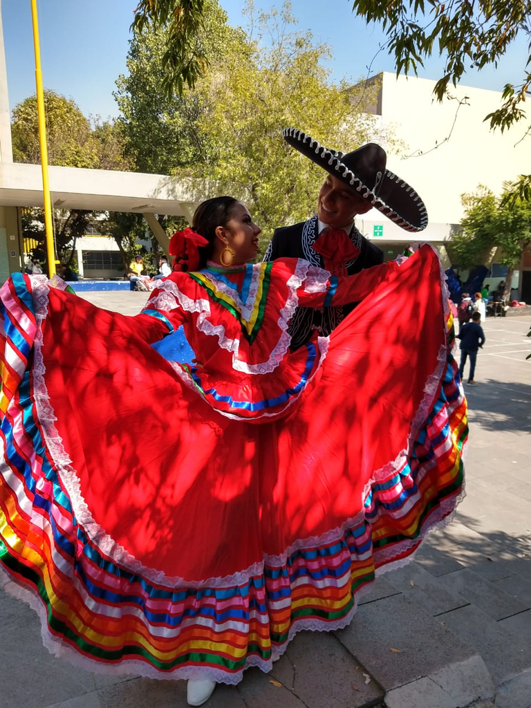

[figure not shown]

[figure not shown]

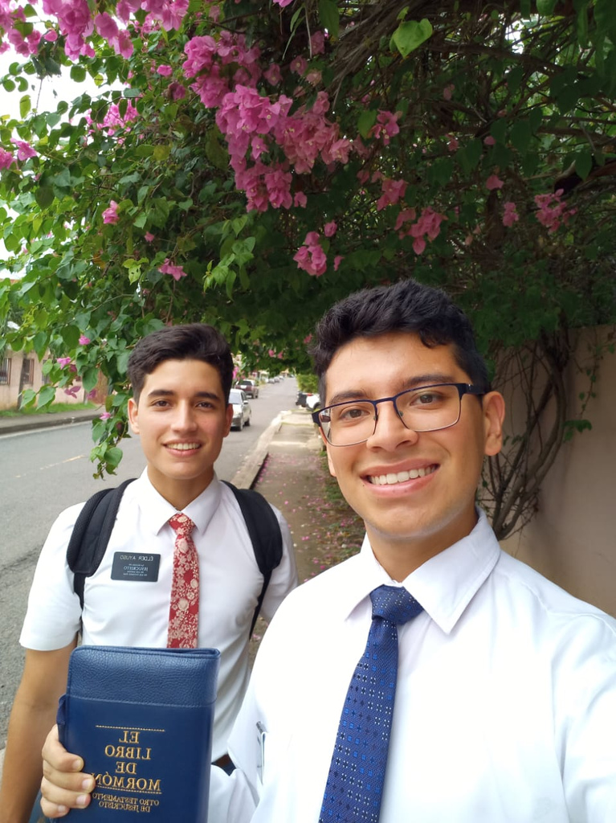